# project3

```r
#install.packages("textdata")
#install.packages("tidytext")
library(tidytext)
library(textdata)
library("here")
library(tidyverse)
rds_files <- c("b_lyrics.RDS", "ts_lyrics.RDS", "sales.RDS")
## Check whether we have all 3 files
if (any(!file.exists(here("data", rds_files)))) {
    ## If we don't, then download the data
    b_lyrics <- readr::read_csv("https://raw.githubusercontent.com/rfordatascience/tidytuesday/master/data/2020/2020-09-29/beyonce_lyrics.csv")
    ts_lyrics <- readr::read_csv("https://raw.githubusercontent.com/rfordatascience/tidytuesday/master/data/2020/2020-09-29/taylor_swift_lyrics.csv")
    sales <- readr::read_csv("https://raw.githubusercontent.com/rfordatascience/tidytuesday/master/data/2020/2020-09-29/sales.csv")

    ## Then save the data objects to RDS files
    saveRDS(b_lyrics, file = here("data", "b_lyrics.RDS"))
    saveRDS(ts_lyrics, file = here("data", "ts_lyrics.RDS"))
    saveRDS(sales, file = here("data", "sales.RDS"))
}

b_lyrics <- readRDS(here("data", "b_lyrics.RDS"))
ts_lyrics <- readRDS(here("data", "ts_lyrics.RDS"))
sales <- readRDS(here("data", "sales.RDS"))
```

# Part 1: Explore album sales

## Part 1A

```r
sales <- sales %>%
  mutate(released = mdy(str_replace(released,"\\(.*\\]","")),
         country = fct_collapse(
           as.factor(country),
           FRA = c("FR","FRA"),
           WW = c("World","WW")),
         sales = sales/1000000
         )%>%
  filter(country %in% c("UK","US","WW"))
sales
```

```
## # A tibble: 36 × 8
##    artist       title        country  sales released   re_release  label formats
##    <chr>        <chr>        <fct>    <dbl> <date>     <chr>       <chr> <chr>
##  1 Taylor Swift Taylor Swift US       5.72  2006-10-24 March 18, … Big … CD, CD…
##  2 Taylor Swift Fearless     WW      12     2008-11-11 October 27… Big … CD, CD…
##  3 Taylor Swift Fearless     US       7.18  2008-11-11 October 27… Big … CD, CD…
##  4 Taylor Swift Fearless     UK       0.609 2008-11-11 October 27… Big … CD, CD…
##  5 Taylor Swift Speak Now    WW       5     2010-10-25 <NA>        Big … CD, CD…
##  6 Taylor Swift Speak Now    US       4.69  2010-10-25 <NA>        Big … CD, CD…
##  7 Taylor Swift Speak Now    UK       0.169 2010-10-25 <NA>        Big … CD, CD…
##  8 Taylor Swift Red          WW       6     2012-10-22 <NA>        Big … CD, CD…
##  9 Taylor Swift Red          US       4.46  2012-10-22 <NA>        Big … CD, CD…
## 10 Taylor Swift Red          UK       0.693 2012-10-22 <NA>        Big … CD, CD…
## # ℹ 26 more rows
```

## Part 1B

```r
sales%>%
  filter(country == "US")%>%
  mutate(years_since_release = floor(time_length(interval(released, today()), "years")))%>%
  group_by(artist)%>%
  summarize(
    most_recent_album = min(years_since_release),
    oldest_album = max(years_since_release),
    median_years_since_album = median(years_since_release)
  )
```

```
## # A tibble: 2 × 4
##   artist       most_recent_album oldest_album median_years_since_album
##   <chr>                    <dbl>        <dbl>                    <dbl>
## 1 Beyoncé                     10           23                       16
## 2 Taylor Swift                 7           20                       14
```

## Part 1C

In each of the subsections below that ask you to create a plot, you must create a title, subtitle, x-axis label, and y-axis label with units where applicable. For example, if your axis says “sales” as an axis label, change it to “sales (in millions)”.

```r
library(scales)
```

```
## `summarise()` has regrouped the output.
## ℹ Summaries were computed grouped by artist and country.
## ℹ Output is grouped by artist.
## ℹ Use `summarise(.groups = "drop_last")` to silence this message.
## ℹ Use `summarise(.by = c(artist, country))` for per-operation grouping
##   (`?dplyr::dplyr_by`) instead.
```

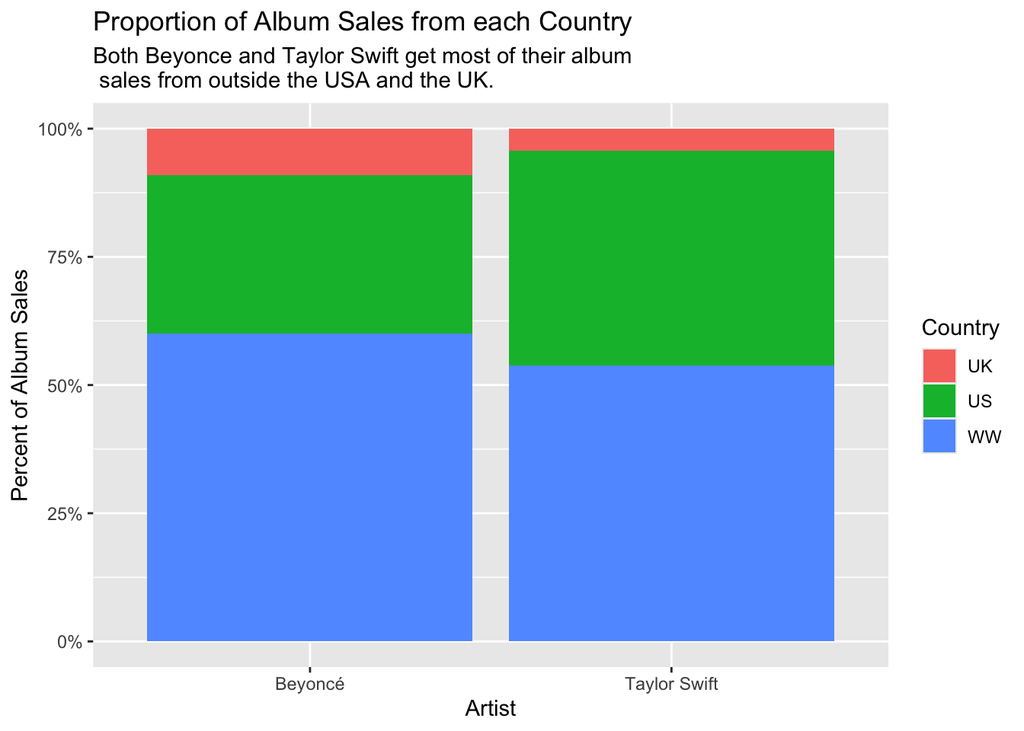

```r
sales %>%
  group_by(artist, country)%>%
  summarize(
    total_album_sales = sum(sales)
  )%>%
  ungroup()%>%
  ggplot(aes(x = artist, y = total_album_sales, fill = country))+
  geom_bar(stat = "identity", position="fill")+
  scale_y_continuous(labels = percent)+
  labs(
    title = "Proportion of Album Sales from each Country",
    subtitle = "Both Beyonce and Taylor Swift get most of their album \n sales from outside the USA and the UK.",
    x = "Artist",
    y = "Percent of Album Sales",
    fill = "Country"
  )
```

## Part 1D

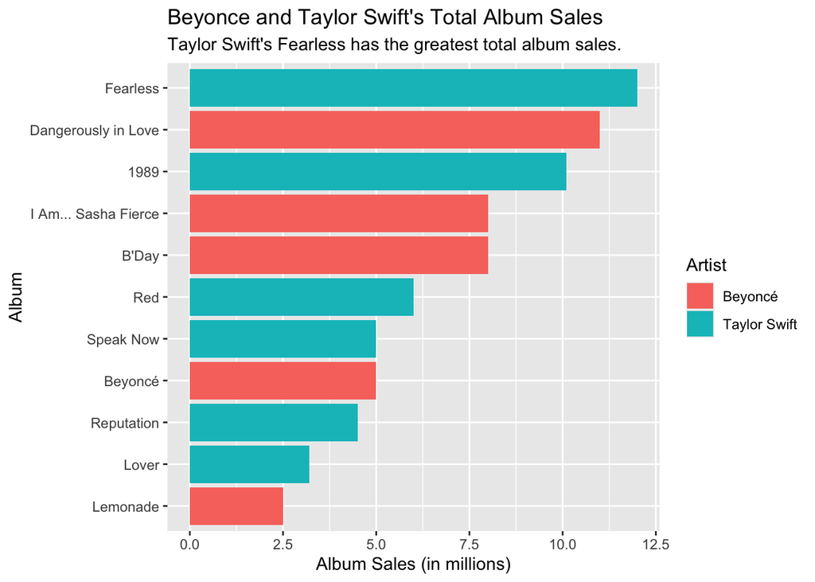

```r
sales%>%
  filter(country == "WW")%>%
  ggplot(aes(x = sales, y = fct_reorder(title,sales), fill = artist))+
  geom_bar(stat = "identity")+
  labs(
    title = "Beyonce and Taylor Swift's Total Album Sales",
    subtitle = "Taylor Swift's Fearless has the greatest total album sales.",
    x = "Album Sales (in millions)",
    y = "Album",
    fill = "Artist"
  )
```

## Part 1E

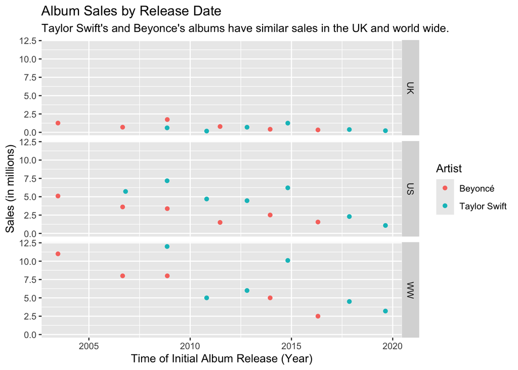

```r
sales%>%
  ggplot(aes(x = released, y = sales, color = artist))+
  geom_point()+
  facet_grid(country ~ .)+
  labs(
    title = "Album Sales by Release Date",
    subtitle = "Taylor Swift's and Beyonce's albums have similar sales in the UK and world wide.",
    x = "Time of Initial Album Release (Year)",
    y = "Sales (in millions)",
    color = "Artist"
  )
```

# Part 2

## Part 2A

Using ts_lyrics, create a new column called line with one line containing the character string for each line of Taylor Swift’s songs.

How many lines in Taylor Swift’s lyrics contain the word “hello”? For full credit, show all the rows in ts_lyrics that have “hello” in the line column and report how many rows there are in total. How many lines in Taylor Swift’s lyrics contain the word “goodbye”? For full credit, show all the rows in ts_lyrics that have “goodbye” in the line column and report how many rows there are in total.

```r
ts_lyrics%>%
  separate_longer_delim(Lyrics, delim = "\n")%>%
  mutate(line = Lyrics)%>%
  filter(str_detect(line,regex("hello", ignore_case = TRUE)))
```

```
## # A tibble: 6 × 5
##   Artist       Album    Title                  Lyrics                      line
##   <chr>        <chr>    <chr>                  <chr>                       <chr>
## 1 Taylor Swift Fearless Love Story             "And say, \"Hello\""        "And…
## 2 Taylor Swift Red      I Almost Do            "That I can't say \"Hello\… "Tha…
## 3 Taylor Swift Red      Everything Has Changed "'Cause all I know is we s… "'Ca…
## 4 Taylor Swift Red      Everything Has Changed "'Cause all I know is we s… "'Ca…
## 5 Taylor Swift Red      Everything Has Changed "All I know is we said hel… "All…
## 6 Taylor Swift Red      Everything Has Changed "All I know is we said hel… "All…
```

```r
ts_lyrics%>%
  separate_longer_delim(Lyrics, delim = "\n")%>%
  mutate(line = Lyrics)%>%
  filter(str_detect(line,regex("goodbye", ignore_case = TRUE)))
```

```
## # A tibble: 12 × 5
##    Artist       Album        Title                      Lyrics             line
##    <chr>        <chr>        <chr>                      <chr>              <chr>
##  1 Taylor Swift Taylor Swift Tied Together With A Smile "Goodbye, baby"    "Goo…
##  2 Taylor Swift Speak Now    Mine                       "Braced myself fo… "Bra…
##  3 Taylor Swift Speak Now    Back to December           "You gave me all … "You…
##  4 Taylor Swift Speak Now    Long Live                  "And force us int… "And…
##  5 Taylor Swift Red          I Almost Do                "And risk another… "And…
##  6 Taylor Swift Red          Come Back Be Here          "Stumbled through… "Stu…
##  7 Taylor Swift 1989         All You Had to Do Was Stay "But people like … "But…
##  8 Taylor Swift reputation   Getaway Car                "Said goodbye in " "Sai…
##  9 Taylor Swift reputation   Getaway Car                "Said goodbye in " "Sai…
## 10 Taylor Swift Lover        Death By A Thousand Cuts   "Saying goodbye i… "Say…
## 11 Taylor Swift Lover        Death By A Thousand Cuts   "'Cause saying go… "'Ca…
## 12 Taylor Swift Lover        Daylight                   "I'll tell you tr… "I'l…
```

There are 10 lines with “goodbye” and 2 lines with “Goodbye”. There are 12 total goodbyes.

## Part 2B

```r
b_lyrics%>%
  filter(str_detect(line,regex("hello", ignore_case = TRUE)))
```

```
## # A tibble: 91 × 6
##    line                        song_id song_name artist_id artist_name song_line
##    <chr>                         <dbl> <chr>         <dbl> <chr>           <dbl>
##  1 Hello world, well I just b… 2220711 "Dreamgi…       498 Beyoncé             5
##  2 Hello Stevie, How you feel… 1981227 "Fingert…       498 Beyoncé             6
##  3 Fellow great Americans, he… 2715227 "FREEDOM…       498 Beyoncé            52
##  4 You had me at hello (Hello)   80249 "Hello"         498 Beyoncé            15
##  5 Hello (Hello)                 80249 "Hello"         498 Beyoncé            16
##  6 Hello (Hello)                 80249 "Hello"         498 Beyoncé            17
##  7 You had me at hello (Hello)   80249 "Hello"         498 Beyoncé            18
##  8 Hello (Hello)                 80249 "Hello"         498 Beyoncé            19
##  9 Hello (Hello)                 80249 "Hello"         498 Beyoncé            20
## 10 'Cause you had me at hello…   80249 "Hello"         498 Beyoncé            24
## # ℹ 81 more rows
```

```r
b_lyrics%>%
  filter(str_detect(line,regex("hello", ignore_case = FALSE)))
```

```
## # A tibble: 32 × 6
##    line                        song_id song_name artist_id artist_name song_line
##    <chr>                         <dbl> <chr>         <dbl> <chr>           <dbl>
##  1 Fellow great Americans, he… 2715227 FREEDOM …       498 Beyoncé            52
##  2 You had me at hello (Hello)   80249 Hello           498 Beyoncé            15
##  3 You had me at hello (Hello)   80249 Hello           498 Beyoncé            18
##  4 'Cause you had me at hello…   80249 Hello           498 Beyoncé            24
##  5 You had me at hello (Hello)   80249 Hello           498 Beyoncé            41
##  6 You had me at hello (Hello)   80249 Hello           498 Beyoncé            44
##  7 You had me at hello (Hello)   80249 Hello           498 Beyoncé            50
##  8 Hello (Hello, hello)          80249 Hello           498 Beyoncé            52
##  9 You had me at hello (Hello)   80249 Hello           498 Beyoncé            62
## 10 You had me at hello (Hello)   80249 Hello           498 Beyoncé            65
## # ℹ 22 more rows
```

There are 91 total hellos with 32 of them being “hello” and the rest being “Hello”.

```r
b_lyrics%>%
  filter(str_detect(line,regex("goodbye", ignore_case = TRUE)))
```

```
## # A tibble: 12 × 6
##    line                        song_id song_name artist_id artist_name song_line
##    <chr>                         <dbl> <chr>         <dbl> <chr>           <dbl>
##  1 We only said goodbye with …  139043 Back to …       498 Beyoncé            12
##  2 We only said goodbye with …  139043 Back to …       498 Beyoncé            21
##  3 We only said goodbye with …  139043 Back to …       498 Beyoncé            24
##  4 Thank God, I found the goo…   51492 Best Thi…       498 Beyoncé            38
##  5 Thank God, I found the goo… 1946060 Best Thi…       498 Beyoncé            42
##  6 Thank God, I found the goo… 4241137 Best Thi…       498 Beyoncé            38
##  7 It's so hard to say goodbye  435491 Gift fro…       498 Beyoncé            23
##  8 I never want to say goodbye  435491 Gift fro…       498 Beyoncé            24
##  9 I never, ever want to say …  435491 Gift fro…       498 Beyoncé            25
## 10 We've got to say goodbye    1844620 Hard To …       498 Beyoncé            29
## 11 Don't have to say goodbye   1224115 Slow Love       498 Beyoncé            42
## 12 Somewhere between hi and g…  141848 Yes             498 Beyoncé            27
```

```r
b_lyrics%>%
  filter(str_detect(line,regex("goodbye", ignore_case = FALSE)))
```

```
## # A tibble: 12 × 6
##    line                        song_id song_name artist_id artist_name song_line
##    <chr>                         <dbl> <chr>         <dbl> <chr>           <dbl>
##  1 We only said goodbye with …  139043 Back to …       498 Beyoncé            12
##  2 We only said goodbye with …  139043 Back to …       498 Beyoncé            21
##  3 We only said goodbye with …  139043 Back to …       498 Beyoncé            24
##  4 Thank God, I found the goo…   51492 Best Thi…       498 Beyoncé            38
##  5 Thank God, I found the goo… 1946060 Best Thi…       498 Beyoncé            42
##  6 Thank God, I found the goo… 4241137 Best Thi…       498 Beyoncé            38
##  7 It's so hard to say goodbye  435491 Gift fro…       498 Beyoncé            23
##  8 I never want to say goodbye  435491 Gift fro…       498 Beyoncé            24
##  9 I never, ever want to say …  435491 Gift fro…       498 Beyoncé            25
## 10 We've got to say goodbye    1844620 Hard To …       498 Beyoncé            29
## 11 Don't have to say goodbye   1224115 Slow Love       498 Beyoncé            42
## 12 Somewhere between hi and g…  141848 Yes             498 Beyoncé            27
```

There are 12 total “goodbye”s.

## Part 2C

```r
#install.packages("stopwords")
library(stopwords)

b_words <- b_lyrics%>%
  mutate(word = str_split(str_to_lower(line), "\\s+"))%>%
  unnest(word)%>%
  mutate(
    word = str_remove_all(word, "[[:punct:]]")
  )%>%
  filter(!word %in% stopwords("en"))%>%
  group_by(word)%>%
  summarise(count =n())%>%
  filter(word != "")%>%
  inner_join(get_sentiments("bing"), by = "word")%>%
  arrange(desc(count))%>%
  slice_max(count,n = 25)
b_words
```

```
## # A tibble: 25 × 3
##    word      count sentiment
##    <chr>     <int> <chr>
##  1 like       1374 positive
##  2 love       1362 positive
##  3 right       463 positive
##  4 good        355 positive
##  5 crazy       308 negative
##  6 top         241 positive
##  7 work        236 positive
##  8 bad         132 negative
##  9 beautiful   131 positive
## 10 well        120 positive
## # ℹ 15 more rows
```

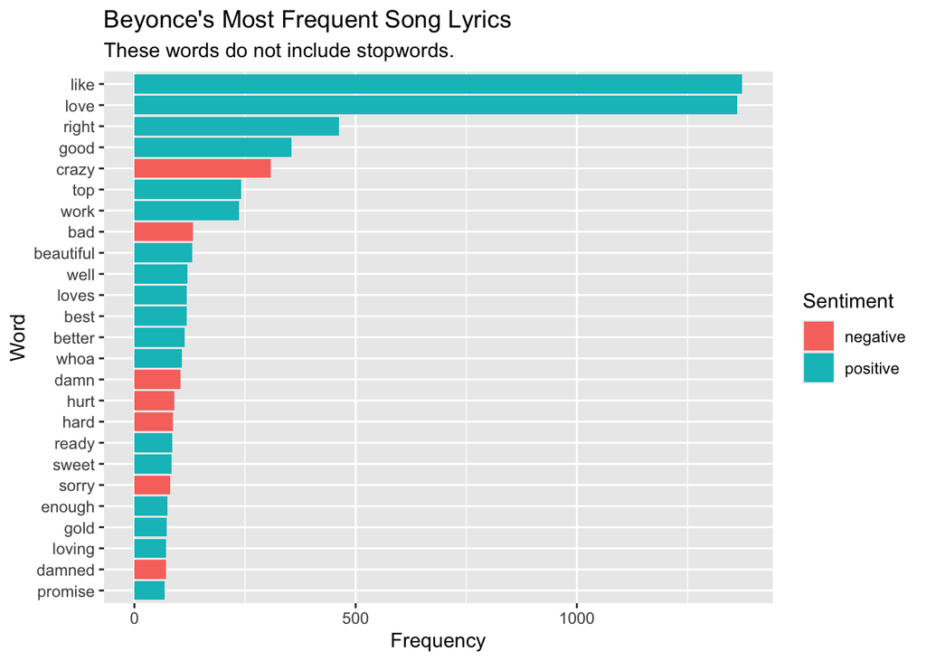

```r
b_words%>%
  ggplot(aes(x = count, y= fct_reorder(word,count), fill = sentiment))+
  geom_bar(stat = "identity")+
  labs(
    title = "Beyonce's Most Frequent Song Lyrics",
    subtitle = "These words do not include stopwords.",
    x = "Frequency",
    y = "Word",
    fill = "Sentiment"
  )
```

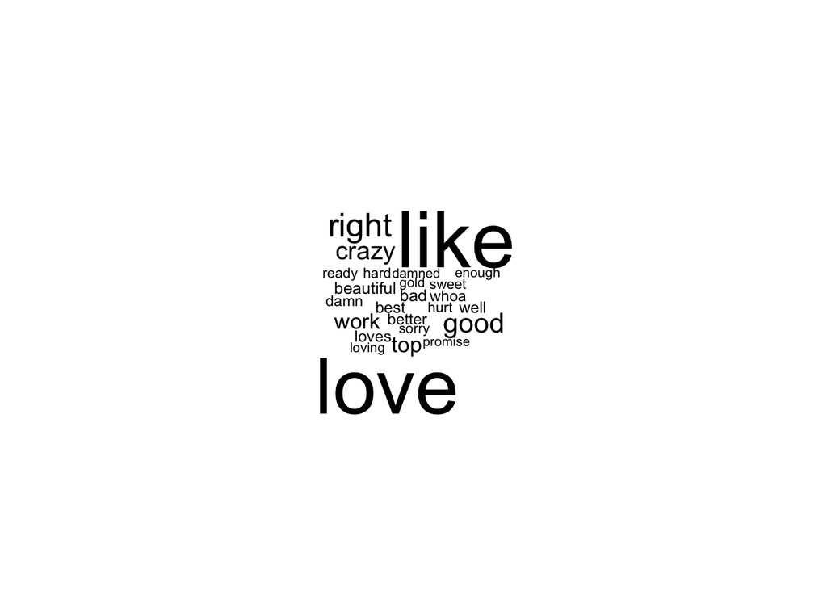

```r
#install.packages("wordcloud")
#install.packages("RColorBrewer")

library(wordcloud)
library(RColorBrewer)

wordcloud(
  words = b_words$word,
  freq = b_words$count
)
```

## Part 2D

I am keeping ties, so I am going to keep 26 words because the tie at place 25 are both words that are technically top 25 frequent words. Please don’t take points away… it feels wrong to get rid of the ties.

```r
ts_lyrics
```

```
## # A tibble: 132 × 4
##    Artist       Album        Title                      Lyrics
##    <chr>        <chr>        <chr>                      <chr>
##  1 Taylor Swift Taylor Swift Tim McGraw                 "He said the way my blu…
##  2 Taylor Swift Taylor Swift Picture to Burn            "State the obvious, I d…
##  3 Taylor Swift Taylor Swift Teardrops on my Guitar     "Drew looks at me,\nI f…
##  4 Taylor Swift Taylor Swift A Place in This World      "I don't know what I wa…
##  5 Taylor Swift Taylor Swift Cold As You                "You have a way of comi…
##  6 Taylor Swift Taylor Swift The Outside                "I didn't know what I w…
##  7 Taylor Swift Taylor Swift Tied Together With A Smile "Seems the only one who…
##  8 Taylor Swift Taylor Swift Stay Beautiful             "Cory's eyes are like a…
##  9 Taylor Swift Taylor Swift Should’ve Said No          "It's strange to think …
## 10 Taylor Swift Taylor Swift Mary’s Song                "She said\n\"I was seve…
## # ℹ 122 more rows
```

```r
ts_words <- ts_lyrics%>%
  separate_longer_delim(Lyrics, delim = "\n")%>%
  mutate(line = Lyrics)%>%
  mutate(word = str_split(str_to_lower(line), "\\s+"))%>%
  unnest(word)%>%
  mutate(
    word = str_remove_all(word, "[[:punct:]]")
  )%>%
  filter(word != "")%>%
  filter(!word %in% stopwords("en"))%>%
  group_by(word)%>%
  summarise(count =n())%>%
  inner_join(get_sentiments("bing"), by = "word")%>%
  arrange(desc(count))%>%
  slice_max(count,n = 25)
ts_words
```

```
## # A tibble: 26 × 3
##    word   count sentiment
##    <chr>  <int> <chr>
##  1 like     406 positive
##  2 love     246 positive
##  3 right    110 positive
##  4 bad       80 negative
##  5 good      76 positive
##  6 better    74 positive
##  7 shake     73 negative
##  8 break     59 negative
##  9 well      59 positive
## 10 best      52 positive
## # ℹ 16 more rows
```

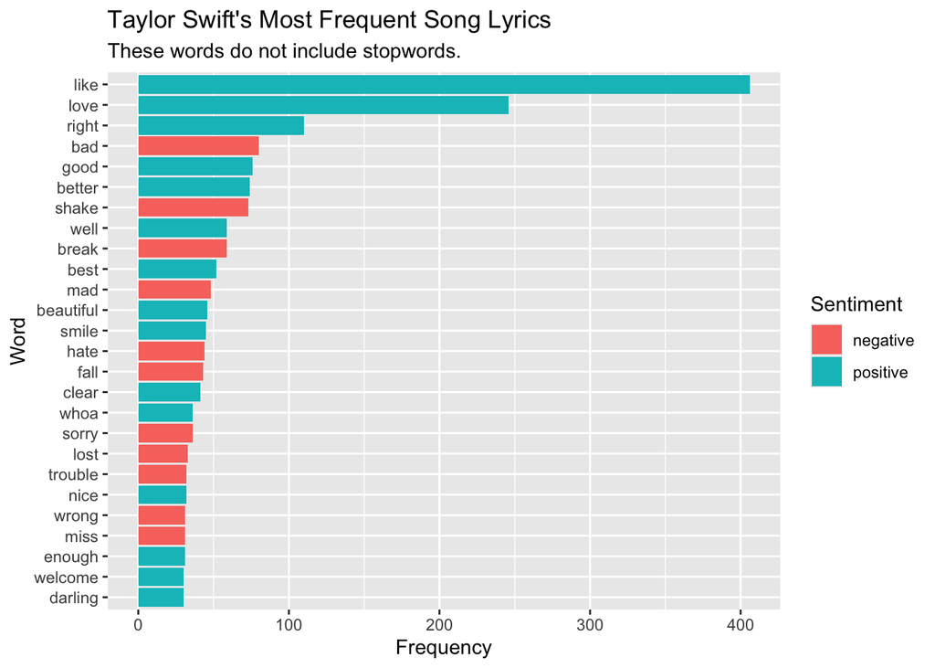

```r
ts_words%>%
  ggplot(aes(x = count, y= fct_reorder(word,count), fill = sentiment))+
  geom_bar(stat = "identity")+
  labs(
    title = "Taylor Swift's Most Frequent Song Lyrics",
    subtitle = "These words do not include stopwords.",
    x = "Frequency",
    y = "Word",
    fill = "Sentiment"
  )
```

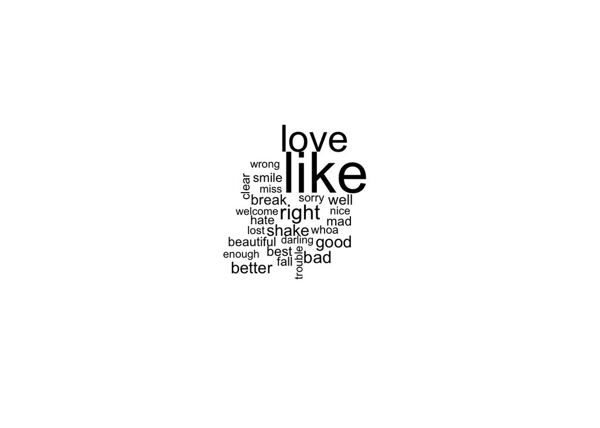

```r
wordcloud(
  words = ts_words$word,
  freq = ts_words$count
)
```

## Part 2E

```r
ts_sent <- ts_lyrics%>%
  separate_longer_delim(Lyrics, delim = "\n")%>%
  mutate(line = Lyrics)%>%
  mutate(word = str_split(str_to_lower(line), "\\s+"))%>%
  unnest(word)%>%
  mutate(
    word = str_remove_all(word, "[[:punct:]]")
  )%>%
  filter(!word %in% stopwords("en"))%>%
  group_by(Album, word)%>%
  summarise(count = n())%>%
  ungroup()%>%
  filter(word != "")%>%
  inner_join(get_sentiments("afinn"), by = "word")%>%
  group_by(Album)%>%
  summarize(avg_sentiment = mean(value))
```

```
## `summarise()` has regrouped the output.
## ℹ Summaries were computed grouped by Album and word.
## ℹ Output is grouped by Album.
## ℹ Use `summarise(.groups = "drop_last")` to silence this message.
## ℹ Use `summarise(.by = c(Album, word))` for per-operation grouping
##   (`?dplyr::dplyr_by`) instead.
```

```r
ts_sent
```

```
## # A tibble: 8 × 2
##   Album        avg_sentiment
##   <chr>                <dbl>
## 1 1989                -0.595
## 2 Fearless             0.192
## 3 Lover               -0.305
## 4 Red                  0.109
## 5 Speak Now           -0.246
## 6 Taylor Swift         0.291
## 7 folklore            -0.418
## 8 reputation          -0.328
```

[figure not shown]

```r
ts_sent%>%
  left_join(sales, by = c("Album" = "title"))%>%
  filter(country == "US")%>%
  ggplot(aes(x = released, y = avg_sentiment, color = Album))+
  geom_point(aes(size = sales))+
  geom_hline(yintercept = 0, color = "red", linetype = "dashed")+
  labs(
    title = "Average Sentiment of Taylor Swift Albums",
    subtitle = "There is a decrease in word sentiment in Taylor Swift's \nlyrics from her debut album to reputation.",
    x = "Release Date",
    y = "Average Sentiment Score",
    color = "Album",
    size = "Album Sales (in millions)"
  )
```